# More Molecular Dynamics

## 10/12/2021

print view

```python
%%html
<script src="http://bits.csb.pitt.edu/asker.js/lib/asker.js"></script>
<script>

require(['https://cdnjs.cloudflare.com/ajax/libs/Chart.js/2.2.2/Chart.js'], function(Ch){
 Chart = Ch;
});

$('head').append('<link rel="stylesheet" href="http://bits.csb.pitt.edu/asker.js/themes/asker.default.css" />');


//the callback is provided a canvas object and data
var chartmaker = function(canvas, labels, data) {
  var ctx = $(canvas).get(0).getContext("2d");
     var dataset = {labels: labels,
    datasets:[{
     data: data,
     backgroundColor: "rgba(150,64,150,0.5)",
         fillColor: "rgba(150,64,150,0.8)",
  }]};
  var myBarChart = new Chart(ctx,{type:'bar',data:dataset,options:{legend: {display:false},
        scales: {
            yAxes: [{
                ticks: {
                    min: 0,
                }
            }]}}});
};

$(".jp-InputArea .o:contains(html)").closest('.jp-InputArea').hide();


</script>
```

```python
%%html
<div id="optrecit" style="width: 500px"></div>
<script>
$('head').append('<link rel="stylesheet" href="http://bits.csb.pitt.edu/asker.js/themes/asker.default.css" />');

    var divid = '#optrecit';
	jQuery(divid).asker({
	    id: divid,
	    question: "Would you attend optional recitations on Wednesday?",
		answers: ["Yes",'No','Maybe'],
        server: "http://bits.csb.pitt.edu/asker.js/example/asker.cgi",
		charter: chartmaker})

$(".jp-InputArea .o:contains(html)").closest('.jp-InputArea').hide();


</script>
```

# MDAnalysis Review

```python
import MDAnalysis
from MDAnalysis.analysis.rms import *  #this pulls in an rmsd function

universe = MDAnalysis.Universe('shmt2.prmtop', 'shmt2.dcd')
prot = universe.select_atoms('protein')

startref = prot.positions
universe.trajectory[-1]
endref = prot.positions

startrmsd = []
endrmsd = []
for ts in universe.trajectory:
    startrmsd.append(rmsd(startref,prot.positions))
    endrmsd.append(rmsd(endref,prot.positions))
```

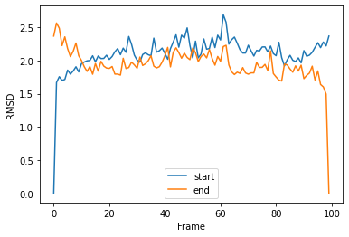

```python
import matplotlib.pyplot as plt
%matplotlib inline

plt.plot(startrmsd,label='start')
plt.plot(endrmsd,label='end')
plt.legend(loc='lower center')
plt.ylabel('RMSD')
plt.xlabel("Frame");
```

# Next Assignment

Calculate rmsds between frames.

[figure not shown]

# MDAnalysis.analysis.contacts

Analysis of native contacts q over a trajectory.

- a “contact” exists between two atoms *i* and *j* if the distance between them is smaller than a given radius
- a “native contact” exists between *i* and *j* if a contact exists and if the contact also exists between the equivalent atoms in a reference structure or conformation

What counts as a contact?

1. Hard Cut: To count as a contact the atoms *i* and *j* have to be at least as close as in the reference structure.
2. Soft Cut: The atom pair *i* and *j* is assigned based on a soft potential ($\lambda = 1.8$ and $\beta = 5.0$ by default) $$Q(r, r_0) = \frac{1}{1 + e^{\beta (r - \lambda r_0)}}$$
3. Radius Cut: To count as a contact the atoms *i* and *j* cannot be further apart then some distance radius.

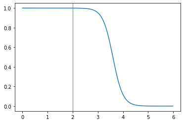

```python
x = np.arange(0.0, 6.0, 0.01)
y = 1.0/(1.0 + np.exp(5.0*(x-1.8*2)))
plt.axvline(2,color='grey',linewidth=1)
plt.plot(x,y);
```

```python
from MDAnalysis.analysis.contacts import *

help(MDAnalysis.analysis.contacts.Contacts)
```

```
Help on class Contacts in module MDAnalysis.analysis.contacts:

class Contacts(MDAnalysis.analysis.base.AnalysisBase)
 |  Contacts(u, select, refgroup, method='hard_cut', radius=4.5, pbc=True, kwargs=None, **basekwargs)
 |  Calculate contacts based observables.
 |  The standard methods used in this class calculate the fraction of native
 |  contacts *Q* from a trajectory.
 |  .. rubric:: Contact API
 |  By defining your own method it is possible to calculate other observables
 |  that only depend on the distances and a possible reference distance. The
 |  **Contact API** prescribes that this method must be a function with call
 |  signature ``func(r, r0, **kwargs)`` and must be provided in the keyword
 |  argument `method`.
 |  Attributes
 |  ----------
 |  results.timeseries : numpy.ndarray
 |      2D array containing *Q* for all refgroup pairs and analyzed frames
 |  timeseries : numpy.ndarray
 |      Alias to the :attr:`results.timeseries` attribute.
 |      .. deprecated:: 2.0.0
 |         Will be removed in MDAnalysis 3.0.0. Please use
 |         :attr:`results.timeseries` instead.
 |  .. versionchanged:: 1.0.0
 |     ``save()`` method has been removed. Use ``np.savetxt()`` on
 |     :attr:`Contacts.results.timeseries` instead.
 |  .. versionchanged:: 1.0.0
 |      added ``pbc`` attribute to calculate distances using PBC.
 |  .. versionchanged:: 2.0.0
 |     :attr:`timeseries` results are now stored in a
 |     :class:`MDAnalysis.analysis.base.Results` instance.
 |  Method resolution order:
 |      Contacts
 |      MDAnalysis.analysis.base.AnalysisBase
 |      builtins.object
 |  Methods defined here:
 |  __init__(self, u, select, refgroup, method='hard_cut', radius=4.5, pbc=True, kwargs=None, **basekwargs)
 |      Parameters
 |      ----------
 |      u : Universe
 |          trajectory
```

[output cut: 31 more lines]

```
 |      ----------
 |      start : int, optional
 |          start frame of analysis
 |      stop : int, optional
 |          stop frame of analysis
 |      step : int, optional
 |          number of frames to skip between each analysed frame
 |      verbose : bool, optional
 |          Turn on verbosity
 |  ----------------------------------------------------------------------
 |  Data descriptors inherited from MDAnalysis.analysis.base.AnalysisBase:
 |  __dict__
 |      dictionary for instance variables (if defined)
 |  __weakref__
 |      list of weak references to the object (if defined)
```

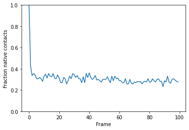

```python
import MDAnalysis
from MDAnalysis.analysis.contacts import *

u = MDAnalysis.Universe('shmt2.prmtop','shmt2.dcd')
sel_basic = "(resname ARG or resname LYS) and (name NH* or name NZ)"
sel_acidic = "(resname ASP or resname GLU) and (name OE* or name OD*)"
acidic = u.select_atoms(sel_acidic)
basic = u.select_atoms(sel_basic)

CA = Contacts(u, select=(sel_acidic, sel_basic), refgroup=(acidic, basic))
CA.run()

plt.plot(CA.results.timeseries[:, 0], CA.results.timeseries[:, 1])
plt.ylim(0,1)
plt.xlabel("Frame"); plt.ylabel("Fraction native contacts");
```

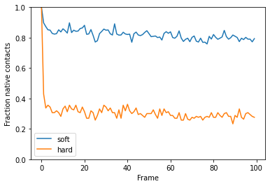

```python
CAsoft = Contacts(u, select=(sel_acidic, sel_basic), refgroup=(acidic, basic),method='soft_cut')
CAsoft.run()

plt.plot(CAsoft.results.timeseries[:, 0], CAsoft.results.timeseries[:, 1],label="soft")
plt.plot(CA.results.timeseries[:, 0], CA.results.timeseries[:, 1],label="hard")
plt.legend(loc='best')
plt.ylim(0,1)
plt.xlabel("Frame"); plt.ylabel("Fraction native contacts");
```

# MDAnalysis.analysis.distances

Analysis of distances between groups of atoms. Precursor to contact analysis.

```python
from MDAnalysis.analysis.distances import *

distarr = distance_array(acidic.positions,basic.positions)
```

```python
import MDAnalysis.analysis.distances
help(MDAnalysis.analysis.distances.distance_array)
```

```
Help on function distance_array in module MDAnalysis.lib.distances:

distance_array(reference, configuration, box=None, result=None, backend='serial')
    Calculate all possible distances between a reference set and another
    configuration.

    If there are ``n`` positions in `reference` and ``m`` positions in
    `configuration`, a distance array of shape ``(n, m)`` will be computed.

    If the optional argument `box` is supplied, the minimum image convention is
    applied when calculating distances. Either orthogonal or triclinic boxes are
    supported.

    If a 2D numpy array of dtype ``numpy.float64`` with the shape ``(n, m)``
    is provided in `result`, then this preallocated array is filled. This can
    speed up calculations.

    Parameters
    ----------
    reference : numpy.ndarray
        Reference coordinate array of shape ``(3,)`` or ``(n, 3)`` (dtype is
        arbitrary, will be converted to ``numpy.float32`` internally).
    configuration : numpy.ndarray
        Configuration coordinate array of shape ``(3,)`` or ``(m, 3)`` (dtype is
        arbitrary, will be converted to ``numpy.float32`` internally).
    box : array_like, optional
        The unitcell dimensions of the system, which can be orthogonal or
        triclinic and must be provided in the same format as returned by
        :attr:`MDAnalysis.coordinates.base.Timestep.dimensions`:
        ``[lx, ly, lz, alpha, beta, gamma]``.
    result : numpy.ndarray, optional
        Preallocated result array which must have the shape ``(n, m)`` and dtype
        ``numpy.float64``.
        Avoids creating the array which saves time when the function
        is called repeatedly.
    backend : {'serial', 'OpenMP'}, optional
        Keyword selecting the type of acceleration.

    Returns
    -------
    d : numpy.ndarray (``dtype=numpy.float64``, ``shape=(n, m)``)
        Array containing the distances ``d[i,j]`` between reference coordinates
        ``i`` and configuration coordinates ``j``.


    .. versionchanged:: 0.13.0
       Added *backend* keyword.
    .. versionchanged:: 0.19.0
       Internal dtype conversion of input coordinates to ``numpy.float32``.
       Now also accepts single coordinates as input.
```

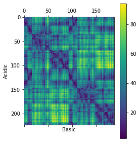

```python
plt.matshow(distarr)
plt.colorbar()
plt.xlabel('Basic'); plt.ylabel('Acidic');
```

```python
%%html
<div id="mdmatrix" style="width: 500px"></div>
<script>
$('head').append('<link rel="stylesheet" href="http://bits.csb.pitt.edu/asker.js/themes/asker.default.css" />');

    var divid = '#mdmatrix';
	jQuery(divid).asker({
	    id: divid,
	    question: "The previous matrix is?",
		answers: ["Gaussian",'Symmetric','Diagonal',
                 'All of the above','None of the above'],
        server: "http://bits.csb.pitt.edu/asker.js/example/asker.cgi",
		charter: chartmaker})

$(".jp-InputArea .o:contains(html)").closest('.jp-InputArea').hide();


</script>
```

# Distance Analysis

Really only interested in short distances

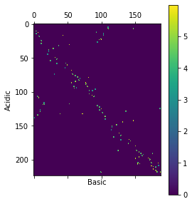

```python
origdistarr = distance_array(acidic.positions,basic.positions)
origdistarr[origdistarr > 6] = 0
plt.matshow(origdistarr)
plt.colorbar()
plt.xlabel('Basic'); plt.ylabel('Acidic');
```

## Analyzing across the trajectory

```python
distarr = np.zeros((acidic.n_atoms, basic.n_atoms))
for ts in u.trajectory:
    distarr += distance_array(acidic.positions,basic.positions)
distarr /= universe.trajectory.n_frames
```

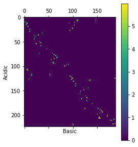

```python
distarr[distarr > 6] = 0
plt.matshow(distarr)
plt.colorbar()
plt.xlabel('Basic'); plt.ylabel('Acidic');
```

```python
%%html
<div id="dmat" style="width: 500px"></div>
<script>
$('head').append('<link rel="stylesheet" href="http://bits.csb.pitt.edu/asker.js/themes/asker.default.css" />');

    var divid = '#dmat';
	jQuery(divid).asker({
	    id: divid,
	    question: "What are the elements of this matrix?",
		answers: ["Max distance",'Final Distance','Average Distance',
                 'Minimum distance'],
        server: "http://bits.csb.pitt.edu/asker.js/example/asker.cgi",
		charter: chartmaker})

$(".jp-InputArea .o:contains(html)").closest('.jp-InputArea').hide();


</script>
```

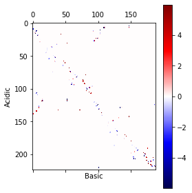

```python
diff = origdistarr - distarr
plt.matshow(diff,cmap='seismic')
clb = plt.colorbar()
clb.set_label('')
plt.xlabel('Basic'); plt.ylabel('Acidic');
```

I'm most interested in the loop from residue 368 to 383 (`resid 368:383`).

How is this loop changing over the course of the simulation (RMSD to first)?

What is happening with the number of hydrogen bonds it is making with the protein?

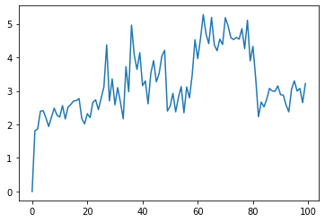

```python
u.trajectory[0]
loop = u.select_atoms('resid 368:383')
ref = loop.positions
rmsds = []
for ts in u.trajectory:
    rmsds.append(rmsd(ref,loop.positions))
plt.plot(rmsds);
```

# Hydrogen Bond analysis

```python
from MDAnalysis.analysis.hydrogenbonds import HydrogenBondAnalysis

h = HydrogenBondAnalysis(u,'resid 368:383','protein')
h.run();
```

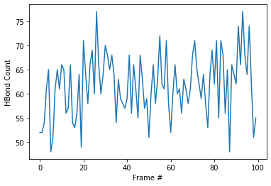

```python
counts = h.count_by_time()
plt.plot(h.frames,h.count_by_time())
plt.xlabel("Frame #"); plt.ylabel("HBond Count");
```

```python
%%html
<div id="hbond1" style="width: 500px"></div>
<script>
$('head').append('<link rel="stylesheet" href="http://bits.csb.pitt.edu/asker.js/themes/asker.default.css" />');

    var divid = '#hbond1';
	jQuery(divid).asker({
	    id: divid,
	    question: "Hydrogen bonds are identified based on?",
		answers: ["Atom types",'Distances','Angles',
                 'All of the above'],
        server: "http://bits.csb.pitt.edu/asker.js/example/asker.cgi",
		charter: chartmaker})

$(".jp-InputArea .o:contains(html)").closest('.jp-InputArea').hide();


</script>
```

Actually, what I'm *really* interested in is comparing SHMT2 and SHMT1...

```python
!wget http://mscbio2025.csb.pitt.edu/files/shmt1.prmtop
!wget http://mscbio2025.csb.pitt.edu/files/shmt1.dcd
```

[output not shown]

# Project

Compare the loop regions (resid 368:383 in SHMT2 vs resid 377:392 in SHMT1)

- Compare the backbone RMSDs
- Compare the hydrogen bonding patterns
- Compare the native contacts

```python
shmt1 = MDAnalysis.Universe('shmt1.prmtop', 'shmt1.dcd')
prot1 = shmt1.select_atoms('protein')
```

```python
prot1.select_atoms('name CA and resid 377:392').resnames
```

```
array(['ASN', 'THR', 'CYS', 'PRO', 'GLY', 'ASP', 'ARG', 'SER', 'ALA',
       'LEU', 'ARG', 'PRO', 'SER', 'GLY', 'LEU', 'ARG'], dtype=object)
```

```python
prot.select_atoms('name CA and resid 368:383').resnames
```

```
array(['ASN', 'THR', 'CYS', 'PRO', 'GLY', 'ASP', 'ARG', 'SER', 'ALA',
       'ILE', 'THR', 'PRO', 'GLY', 'GLY', 'LEU', 'ARG'], dtype=object)
```